# Semantix Challenge - First Part

Rui Romanini

10 de novembro de 2016

In this challenge, suppose we are looking to do social network analysis for prospective customers. We want to extract from their social network a metric called “closeness centrality”.

Centrality metrics try to approximate a measure of influence of an individual within a social network. The distance between any two vertices is their shortest path. The *farness* of a given vertex *v* is the sum of all distances from each vertex to *v*. Finally, the *closeness* of a vertex *v* is the inverse of the *farness*.

The first part of the challenge is to rank the vertices in a given graph by their *closeness*. The graph is provided in the attached file; each line of the file consists of two vertex names separated by a single space, representing an edge between those two nodes.

## The environment

It’s important to pay atention to the environment, to make sure about reproducibility.

This code was produced using R version 3.3.1 and R Studio version 0.99.489

The Operational System it’s Windows 10 Home

## Reading the graph

```r
vertices <- read.csv("C:\\Rui\\Data Science\\teste\\edges.dat" ,sep = " ",header = FALSE)
```

## Creating the graph from the data frame

Now we can build the net from the vertices

```r
install.packages("igraph", repos = "http://cran.us.r-project.org")
library(igraph)
net <-graph_from_data_frame(d=vertices,directed = T)
```

## Creating the plot

Now we can build the plot showing the nodes and connections

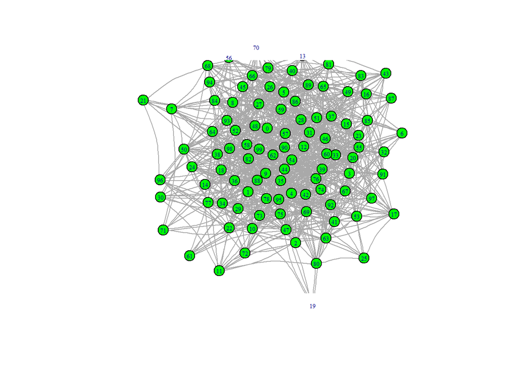

```r
l <- layout_with_fr(net)
l <- norm_coords(l, ymin=-1, ymax=1, xmin=-1, xmax=1)

plot(net,edge.arrow.size=.05,vertex.size=10,
     edge.curved=0.2,
     vertex.frame.color="black",
     vertex.color="green",
     vertex.label.cex=0.5,rescale=F, layout=l*1.2)
```

## Getting the Closeness

Now we can build the closeness

```r
closeness(net, mode="all", weights=NA)
```

```
##          64          70          80          37          36          13
## 0.005434783 0.005263158 0.005102041 0.005617978 0.005376344 0.005524862
##          26          77          69          82          95           5
## 0.005555556 0.005405405 0.005649718 0.005714286 0.005586592 0.005780347
##          90          65          51          47          18          39
## 0.005586592 0.005555556 0.005813953 0.005617978 0.005464481 0.005464481
##           2          99          25          34          54          41
## 0.005319149 0.005649718 0.004854369 0.005405405 0.005617978 0.005555556
##          79          53          21          38          88          10
## 0.005464481 0.005319149 0.004926108 0.005434783 0.005917160 0.005555556
##          29          78           9          68          67          97
## 0.005617978 0.005586592 0.005649718 0.005154639 0.005586592 0.005555556
##          83          49           0          35          52          93
## 0.005154639 0.005376344 0.005434783 0.005681818 0.005464481 0.005524862
##          17           8          33          96          73          98
## 0.005319149 0.005617978 0.005882353 0.005102041 0.005714286 0.005714286
##          58          84          57          46           3           4
## 0.005376344 0.005434783 0.005714286 0.005494505 0.005555556 0.005555556
##          48          63          72          24          87          15
## 0.005555556 0.005405405 0.005128205 0.005405405 0.005050505 0.005586592
##          14          44          16          30          40          56
## 0.005376344 0.005988024 0.005291005 0.005076142 0.005347594 0.005076142
##          94          28          91          42           1          32
## 0.004975124 0.005714286 0.005319149 0.005494505 0.005617978 0.005208333
##           6          59          76          55          11          23
## 0.005208333 0.005434783 0.005747126 0.005494505 0.005025126 0.005494505
##          45          85          89          12          43          74
## 0.005494505 0.005102041 0.005747126 0.005555556 0.005025126 0.005847953
##          31          86          75          27          66          60
## 0.005524862 0.005494505 0.005524862 0.005405405 0.005586592 0.005291005
##           7          20          50          81          92          62
## 0.005076142 0.005813953 0.005524862 0.005376344 0.005649718 0.005649718
##          71          22          19          61
## 0.004784689 0.005434783 0.004672897 0.004854369
```

```r
centr_clo(net, mode="all", normalized=T)
```

```
## $res
##   [1] 0.5380435 0.5210526 0.5051020 0.5561798 0.5322581 0.5469613 0.5500000
##   [8] 0.5351351 0.5593220 0.5657143 0.5530726 0.5722543 0.5530726 0.5500000
##  [15] 0.5755814 0.5561798 0.5409836 0.5409836 0.5265957 0.5593220 0.4805825
##  [22] 0.5351351 0.5561798 0.5500000 0.5409836 0.5265957 0.4876847 0.5380435
##  [29] 0.5857988 0.5500000 0.5561798 0.5530726 0.5593220 0.5103093 0.5530726
##  [36] 0.5500000 0.5103093 0.5322581 0.5380435 0.5625000 0.5409836 0.5469613
##  [43] 0.5265957 0.5561798 0.5823529 0.5051020 0.5657143 0.5657143 0.5322581
##  [50] 0.5380435 0.5657143 0.5439560 0.5500000 0.5500000 0.5500000 0.5351351
##  [57] 0.5076923 0.5351351 0.5000000 0.5530726 0.5322581 0.5928144 0.5238095
##  [64] 0.5025381 0.5294118 0.5025381 0.4925373 0.5657143 0.5265957 0.5439560
##  [71] 0.5561798 0.5156250 0.5156250 0.5380435 0.5689655 0.5439560 0.4974874
##  [78] 0.5439560 0.5439560 0.5051020 0.5689655 0.5500000 0.4974874 0.5789474
##  [85] 0.5469613 0.5439560 0.5469613 0.5351351 0.5530726 0.5238095 0.5025381
##  [92] 0.5755814 0.5469613 0.5322581 0.5593220 0.5593220 0.4736842 0.5380435
##  [99] 0.4626168 0.4805825
##
## $centralization
## [1] 0.1096407
##
## $theoretical_max
## [1] 49.24873
```